# **Project Name** - Play Store App review analysis EDA

## *4. Data Vizualization, Storytelling & Experimenting with charts : Understand the relationships between variables*

#### Chart 01-- Distribution **of** Free and Paid App

```python
# To group paid apps and free apps and specifying number of apps
Type_df=df1.groupby('Type')[['App']].count().reset_index()
```

```python
Type_df
```

|  | Type | App |
| --- | --- | --- |
| 0 | Free | 8897 |
| 1 | Paid | 750 |

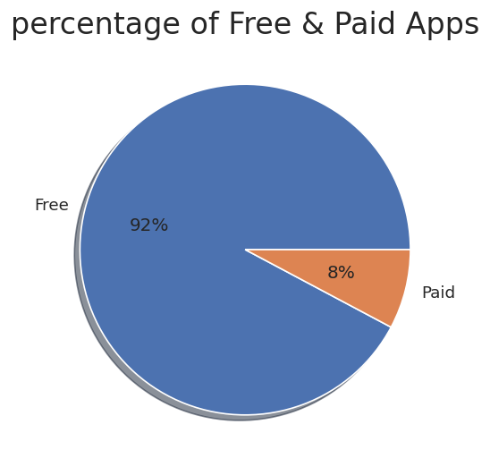

```python
# Chart - 01 visualization code pie chart

# Create a new figure and axis object
fig, ax = plt.subplots()

label_names = ['Free', 'Paid']

# Plot the data as a pie chart
ax.pie(Type_df['App'], labels=label_names, autopct='%1.00f%%', shadow=True, startangle=0)

# Set the title
ax.set_title('percentage of Free & Paid Apps',fontsize=20)

# Show the chart
plt.show()
```

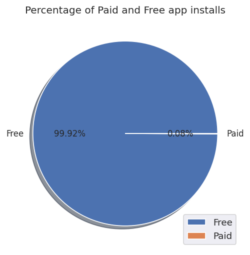

```python
# Extracting number of installs in free and paid app types

free_paid_install = df1.groupby(['Type'])['Installs'].sum()

# Ploting pie chart

plt.figure(figsize=(5,5))
plt.pie(free_paid_install, labels = label_names,autopct='%.2f%%',textprops={'fontsize': 10},shadow=True)
plt.title('Percentage of Paid and Free app installs',size=12,loc='center')
plt.legend(loc='lower right')
plt.show()
```

Answer: The pie chart can show the proportion of paid and free apps in the market.

##### 2. What is/are the insight(s) found from the chart?

Answer:

A. **Proportion**

1. From this graph we can observe that 92% of the apps available are free of cost with 99.92 % installs.
2. While only 8% of the apps available are of paid type with 0.08% of downloads.

B. **User preference**

Pie chart showing that most of the users are likely to download free apps over paid apps.

**C. Revenue:**

If developer planning to launch new app its quite obvious that chances of good revenue generation from paid app is quite less, on other hands as number of free apps are available on huge amount develper have to depend on different menthods like in-app purchase, or Advertisement.

##### 3. Will the gained insights help creating a positive business impact?

Are there any insights that lead to negative growth? Justify with specific reason.

Answer:

positive business impact: From the pie chart given above we can easily notice that audience are more likely to interested in FREE apps as compared to PAID apps. along with that the pie chart also shows the level of competition in Paid app category is very less as compared to FREE apps as compition is tough and developer have to work hand in order to stand out in the market.

Negative business impact:As from Installs pie chart percentage of installs for paid apps is 0.08% only. Hence,it is quite difficult for PAID apps to reach huge user base because user preference is more towards FREE apps.

#### Chart 02-- Distribution of Content Rating on Play Store.

```python
# Applying groupby on content rating column and getting number of apps
Content_df=df1.groupby(['Content Rating'])['App'].count().reset_index()

# Creating new column 'Percentage' to identify percentage distribution of each content rating
Content_df['Percentage'] = round(Content_df['App'] / Content_df['App'].sum() * 100, 2)
```

```python
# Chart - 2 visualization code donut chart

fig = px.pie(Content_df, values='App', names='Content Rating', title='Content Rating Distribution', width=1000, height=500, hole=0.5)

# Show legend
fig.update_traces(showlegend=True)

# Show the plot
fig.show()
```

[interactive chart not shown]

```python
# Sorting content rating percentages in descending order
Content_df.sort_values(by=['Percentage'],ascending=False)
```

|  | Content Rating | App | Percentage |
| --- | --- | --- | --- |
| 1 | Everyone | 7893 | 81.82 |
| 4 | Teen | 1035 | 10.73 |
| 3 | Mature 17+ | 393 | 4.07 |
| 2 | Everyone 10+ | 321 | 3.33 |
| 0 | Adults only 18+ | 3 | 0.03 |
| 5 | Unrated | 2 | 0.02 |

##### 1. Why did you pick the specific chart?

Answer:

a pie chart is an effective way to represent the relative distribution of different content rating categories in the app store. It allows the viewer to quickly see the proportion of apps in each category.

##### 2. What is/are the insight(s) found from the chart?

Answer:

1. The majority of the apps on the play store have a content rating of "Everyone", with a share of 81.8%.
2. The remaining content ratings, i.e., "Everyone 10+", "Teen", "Mature 17+", and "Adults only 18+", have a significantly lower share.
3. The content rating "Adults only 18+" has the smallest share, with only 0.03% of apps falling under this category.
4. The content rating "Unrated" has an almost negligible share of 0.02%.

##### 3. Will the gained insights help creating a positive business impact?

Are there any insights that lead to negative growth? Justify with specific reason.

Answer:

**Positive Impact:** From the above pie chart we can confidently say that most of the apps available on Playstore are suitable for childrens.

**Negative Impact**: There is no direct negative impact as such but from pie chart it is quite clear that 'Adults only 18+' shares only 0.03% and unrated apps shares 0.02% of overall apps available on playstore, so investing in such categories may not be a profitable strategy.

#### Chart 03-- What is the distribution of Price and Rating in Play Store?

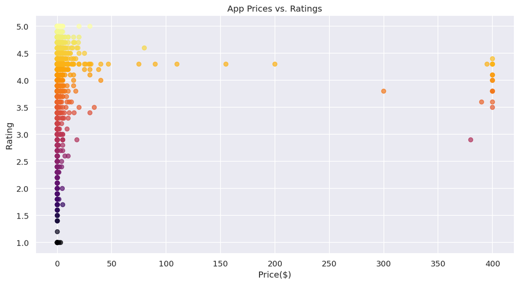

```python
# Chart - 03 visualization code scatter plot
plt.figure(figsize=(12,6))
plt.scatter(x='Price', y='Rating', data=df1, alpha=0.7,cmap='inferno',c='Rating')
plt.title('App Prices vs. Ratings')
plt.xlabel('Price($)')
plt.ylabel('Rating')
plt.show()
```

```python
# To get mean rating of apps having price greater than $20
df1[df1['Price']<=20].describe()
```

|  | Rating | Reviews | Size | Installs | Price | Revenue |
| --- | --- | --- | --- | --- | --- | --- |
| count | 9608.000000 | 9.608000e+03 | 8383.000000 | 9.608000e+03 | 9608.000000 | 9.608000e+03 |
| mean | 4.192194 | 2.177395e+05 | 20.412400 | 7.818749e+06 | 0.283676 | 2.082236e+04 |
| std | 0.496646 | 1.836106e+06 | 21.831584 | 5.389779e+07 | 1.377133 | 7.391927e+05 |
| min | 1.000000 | 0.000000e+00 | 0.008301 | 0.000000e+00 | 0.000000 | 0.000000e+00 |
| 25% | 4.000000 | 2.500000e+01 | 4.600000 | 1.000000e+03 | 0.000000 | 0.000000e+00 |
| 50% | 4.300000 | 9.940000e+02 | 12.000000 | 1.000000e+05 | 0.000000 | 0.000000e+00 |
| 75% | 4.500000 | 2.970600e+04 | 28.000000 | 1.000000e+06 | 0.000000 | 0.000000e+00 |
| max | 5.000000 | 7.815831e+07 | 100.000000 | 1.000000e+09 | 19.990000 | 6.990000e+07 |

##### 1. Why did you pick the specific chart?

Answer: the scatter plot can show us the distribution of apps across a range of prices and ratings, and helps to find out whether there is any correlation between price and rating of apps in the Play Store.

##### 2. What is/are the insight(s) found from the chart?

Answer:

1. Most of the apps available on Playstore are FREE (Price $0) having rating within range 3.5 to 4.5.
2. Most of the apps lies in the $$0 to $30 range.
3. Very few apps available on playstore which costs high($300 to $500)
4. Majority of apps having ratings from 3 to 5 which indicates that most of the apps are well liked by users irrespective of price.

##### 3. Will the gained insights help creating a positive business impact?

Are there any insights that lead to negative growth? Justify with specific reason.

Answer:

Negative Impact: The wide range of prices for paid apps can make it difficult for users to find apps within their budget, leading to frustration and lower app downloads. Outliers in the data suggest that some apps are not providing good value for money, leading to negative reviews and a decline in user trust.

#### Chart 04-- What is the most popular app size range?

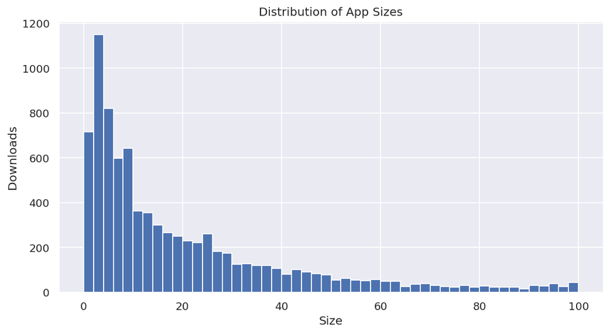

```python
# Chart - 04 visualization code histogram
# Plotting a histogram of the app sizes

plt.hist(df1['Size'], bins=50)

# Customize the chart appearance and layout
plt.title('Distribution of App Sizes')
plt.xlabel('Size')
plt.ylabel('Downloads')
plt.grid(True)
plt.show()
```

##### 1. Why did you pick the specific chart?

Answer. The histogram of app sizes can provide several insights into the distribution of app sizes in the dataset

##### 2. What is/are the insight(s) found from the chart?

Answer:

1. Most of the apps have a size less than 40 MB, and there are very few apps that have a size greater than 60 MB.
2. From the histogram it is clearly visible that the size data is skrewed at right side which indicates more apps with small size, and fews apps with large size is available on playstore.

##### 3. Will the gained insights help creating a positive business impact?

Are there any insights that lead to negative growth? Justify with specific reason.

Answer

#### Chart 05-- What is the correlation between app size and rating?

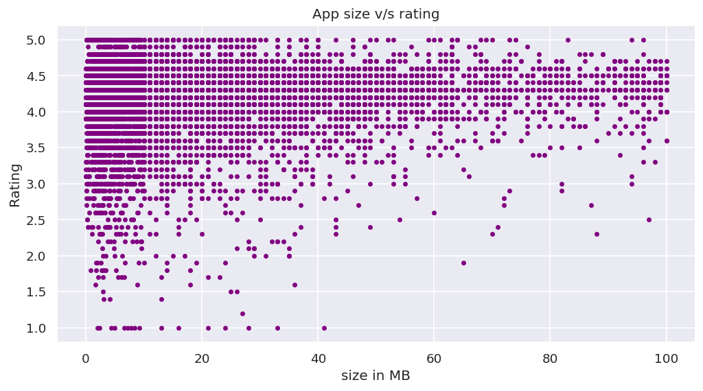

```python
# Chart - 05 visualization code scatter plot

# Create a new figure and axis object
fig, ax = plt.subplots()
# Plot the data as a scatter plot
ax.scatter(df1['Size'],df1['Rating'], color='purple', marker='o', s=10)

# Set the title and axis labels
ax.set_title('App size v/s rating')
ax.set_xlabel('size in MB')
ax.set_ylabel('Rating')

ax.grid(True)

# Show the chart
plt.show()
```

##### 1. Why did you pick the specific chart?

Answer:

The scatter plot is a useful type of graph for visualizing the relationship between two continuous variables. It plots the relationship between the size of an app (in MB) and its rating.

##### 3. Will the gained insights help creating a positive business impact?

Are there any insights that lead to negative growth? Justify with specific reason.

Answer:

Positive Impact: Developers should create efficient and lightweight apps to attract and retain users and save on storage and data costs.

Negative Impact: The graph doesn't indicate any clear negative business impact, but in order to prevent bad reviews and low ratings, businesses should put the user experience first.

#### Chart 06-- What is the most popular app category in terms of the counts?

```python
# Applying group by on category column and getting count of apps in each category
category_count=df1.groupby('Category')[['App']].count().reset_index()
```

```python
# Sorting categories app count by descending order
category_count.sort_values(by='App',ascending=False)
```

|  | Category | App |
| --- | --- | --- |
| 11 | FAMILY | 1829 |
| 14 | GAME | 955 |
| 29 | TOOLS | 826 |
| 4 | BUSINESS | 420 |
| 20 | MEDICAL | 394 |
| 23 | PERSONALIZATION | 375 |
| 25 | PRODUCTIVITY | 374 |
| 18 | LIFESTYLE | 368 |
| 12 | FINANCE | 345 |
| 28 | SPORTS | 325 |
| 6 | COMMUNICATION | 315 |
| 15 | HEALTH_AND_FITNESS | 288 |
| 24 | PHOTOGRAPHY | 281 |
| 21 | NEWS_AND_MAGAZINES | 254 |
| 27 | SOCIAL | 238 |
| 3 | BOOKS_AND_REFERENCE | 222 |
| 30 | TRAVEL_AND_LOCAL | 219 |
| 26 | SHOPPING | 202 |
| 7 | DATING | 171 |
| 31 | VIDEO_PLAYERS | 163 |
| 19 | MAPS_AND_NAVIGATION | 131 |
| 8 | EDUCATION | 119 |
| 13 | FOOD_AND_DRINK | 112 |
| 9 | ENTERTAINMENT | 102 |
| 1 | AUTO_AND_VEHICLES | 85 |
| 17 | LIBRARIES_AND_DEMO | 84 |
| 32 | WEATHER | 79 |
| 16 | HOUSE_AND_HOME | 74 |
| 10 | EVENTS | 64 |
| 0 | ART_AND_DESIGN | 64 |
| 22 | PARENTING | 60 |
| 5 | COMICS | 56 |
| 2 | BEAUTY | 53 |

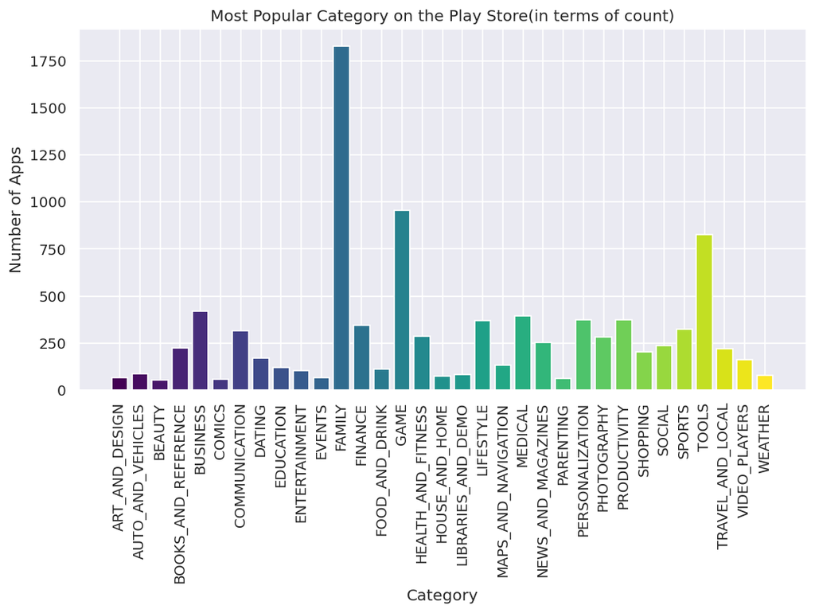

```python
# Chart - 6.1 visualization code bar chart

# plt.figure(figsize=(10, 8))
colors = plt.cm.viridis(np.linspace(0, 1, len(category_count['Category'])))
plt.bar(category_count['Category'],category_count['App'], color=colors)
plt.xticks(rotation=90)
plt.xlabel('Category')
plt.ylabel('Number of Apps')
plt.title('Most Popular Category on the Play Store(in terms of count)')
plt.show()
```

```python
# Chart - 6.2 visualization code donut chart


labels = category_count['Category']
values = category_count['App']

fig = go.Figure(data=[go.Pie(labels=labels, values=values,
                             textinfo='percent', insidetextorientation='radial')])

fig.update_traces(hole=0.4, hoverinfo='label+percent+name',
                  marker=dict(line=dict(color='#000000', width=1)))

fig.update_layout(title='Percentage distribution of apps in each Category',
                  showlegend=True,
                  width=1200,
                  height=800,
                  margin=dict(l=50, r=50, b=100, t=100, pad=4),
                  paper_bgcolor='rgb(243, 243, 243)',
                  plot_bgcolor='rgb(243, 243, 243)',
                  font=dict(family='Arial, sans-serif', size=15, color='#000000'))

fig.show()
```

[interactive chart not shown]

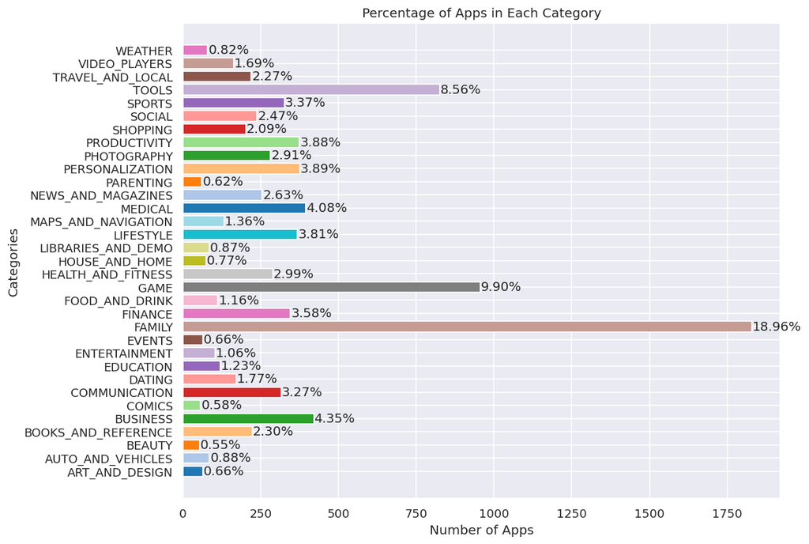

```python
# Chart - 6.3 visualization code bar chart
# Data for the bar chart
categories = category_count['Category']
num_apps = category_count['App']

# Calculate percentages
total_apps = sum(num_apps)
percentages = [(num_app/total_apps)*100 for num_app in num_apps]

# Create bar chart
fig = plt.figure(figsize=(10, 8))
colors = plt.get_cmap('tab20').colors
plt.barh(categories, num_apps, color=colors)

# Add percentages as text on each bar
for i in range(len(categories)):
    plt.text(num_apps[i]+2, i, f'{percentages[i]:.2f}%', va='center')

# Add axis labels and title
plt.xlabel('Number of Apps')
plt.ylabel('Categories')
plt.title('Percentage of Apps in Each Category')

# Show the chart
plt.show()
```

##### 1. Why did you pick the specific chart?

Answer: A **bar chart** allows viewers to easily compare the number of apps in different categories. The viewer can quickly see which categories have the most or fewest apps.

A **pie chart** is a simple and intuitive way to represent the distribution of different categories of apps. The viewer can quickly and easily understand the proportion of each category of apps

##### 2. What is/are the insight(s) found from the chart?

Answer:

1. Most of the Apps available on playstore are from FAMILY category having 1829 apps and 19% of proportion.
2. Only 53 apps are available from BEAUTY category having share of 0.549%.

##### 3. Will the gained insights help creating a positive business impact?

Are there any insights that lead to negative growth? Justify with specific reason.

Answer:

Positive business Impact:

Categories such as Family, Games, Tools, and Productivity have a large number of apps, indicating that they are likely popular among users.

Negative business impact:

Categories with fewer apps, such as Weather, House and Home, and Comics, may have a smaller market and therefore may not have as much potential for business growth.

#### Chart 07-- What is the most popular app category in terms of the number of downloads?

```python
# To identify category wise Installs
download_count=df1.groupby('Category')[['Installs']].sum().reset_index()
```

```python
# Adding new column 'Percentage' for category distribution.
download_count['Percentage']=((download_count['Installs']/download_count['Installs'].sum())*100).round(2)
```

```python
# Sorting Install values in descending order
download_count.sort_values(by='Installs',ascending=False)
```

|  | Category | Installs | Percentage |
| --- | --- | --- | --- |
| 14 | GAME | 13878924398 | 18.47 |
| 6 | COMMUNICATION | 11038276251 | 14.69 |
| 29 | TOOLS | 8001771905 | 10.65 |
| 25 | PRODUCTIVITY | 5793091369 | 7.71 |
| 27 | SOCIAL | 5487867892 | 7.31 |
| 24 | PHOTOGRAPHY | 4649147655 | 6.19 |
| 11 | FAMILY | 4427941494 | 5.89 |
| 31 | VIDEO_PLAYERS | 3926902720 | 5.23 |
| 30 | TRAVEL_AND_LOCAL | 2894887146 | 3.85 |
| 21 | NEWS_AND_MAGAZINES | 2369217760 | 3.15 |
| 9 | ENTERTAINMENT | 2113660000 | 2.81 |
| 3 | BOOKS_AND_REFERENCE | 1665969576 | 2.22 |
| 23 | PERSONALIZATION | 1532494781 | 2.04 |
| 26 | SHOPPING | 1400348785 | 1.86 |
| 15 | HEALTH_AND_FITNESS | 1144022512 | 1.52 |
| 28 | SPORTS | 1096474498 | 1.46 |
| 4 | BUSINESS | 697164865 | 0.93 |
| 18 | LIFESTYLE | 503813539 | 0.67 |
| 19 | MAPS_AND_NAVIGATION | 503281890 | 0.67 |
| 12 | FINANCE | 455348734 | 0.61 |
| 32 | WEATHER | 361100520 | 0.48 |
| 8 | EDUCATION | 352952000 | 0.47 |
| 13 | FOOD_AND_DRINK | 211798751 | 0.28 |
| 7 | DATING | 140926107 | 0.19 |
| 0 | ART_AND_DESIGN | 114338100 | 0.15 |
| 16 | HOUSE_AND_HOME | 97212461 | 0.13 |
| 1 | AUTO_AND_VEHICLES | 53130211 | 0.07 |
| 17 | LIBRARIES_AND_DEMO | 52995910 | 0.07 |
| 5 | COMICS | 44981150 | 0.06 |
| 20 | MEDICAL | 38193176 | 0.05 |
| 22 | PARENTING | 31521110 | 0.04 |
| 2 | BEAUTY | 27197050 | 0.04 |
| 10 | EVENTS | 15973161 | 0.02 |

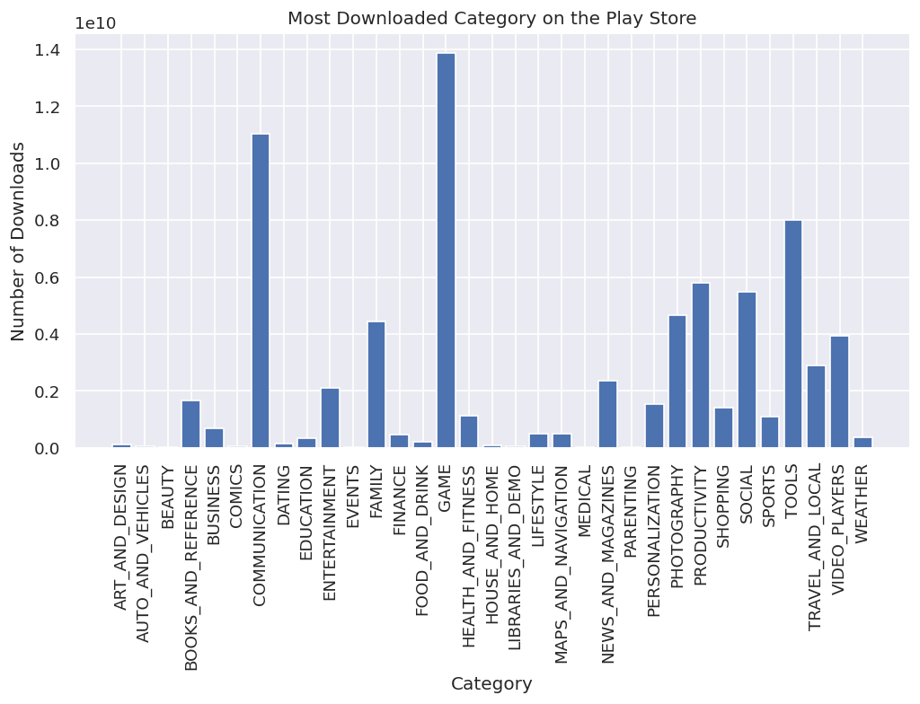

```python
# Chart - 07 visualization code
# Visualize the results using a bar chart

# plt.figure(figsize=(10, 8))
plt.bar(download_count['Category'],download_count['Installs'])
plt.xticks(rotation=90)
plt.xlabel('Category')
plt.ylabel('Number of Downloads')
plt.title('Most Downloaded Category on the Play Store')
plt.show()
```

```python
# Chart - 7.1 visualization code
# Create the line chart using Plotly
fig = px.bar(download_count, x='Percentage',y='Category', title='Percentage Distribution per category',width=1200, height=600)
fig.update_traces(marker={'color':'Green'})
fig.show()
```

[interactive chart not shown]

##### 1. Why did you pick the specific chart?

Answer: A **bar chart** allows viewers to easily compare the number of downloads in different categories. The viewer can quickly see which categories have the most or least downloaded apps.

##### 2. What is/are the insight(s) found from the chart?

Answer:

##### 3. Will the gained insights help creating a positive business impact?

Are there any insights that lead to negative growth? Justify with specific reason.

Answer

Positive business Impact:

The "GAME" and "COMMUNICATION" category has the highest percentage of downloads, which indicates that developing games can be a profitable business.

Negative business Impact: The "BEAUTY" and "EVENTS" categories have a very low percentage of downloads, which may indicate that there is little demand for these types of apps in the market.

#### Chart 08-- Which app category have highest average price of installation?

```python
# Applying groupby on category column and get mean price of each category
category_avg_price=df1.groupby('Category')[['Price']].mean().reset_index()
```

```python
# Sorting average prices by descending order
category_avg_price.sort_values(by='Price',ascending=False)
```

|  | Category | Price |
| --- | --- | --- |
| 12 | FINANCE | 8.408203 |
| 18 | LIFESTYLE | 6.408641 |
| 20 | MEDICAL | 2.527157 |
| 10 | EVENTS | 1.718594 |
| 11 | FAMILY | 1.311575 |
| 25 | PRODUCTIVITY | 0.670936 |
| 3 | BOOKS_AND_REFERENCE | 0.539505 |
| 24 | PHOTOGRAPHY | 0.420925 |
| 4 | BUSINESS | 0.417357 |
| 32 | WEATHER | 0.410380 |
| 23 | PERSONALIZATION | 0.398640 |
| 29 | TOOLS | 0.322349 |
| 28 | SPORTS | 0.307692 |
| 14 | GAME | 0.295110 |
| 6 | COMMUNICATION | 0.263937 |
| 30 | TRAVEL_AND_LOCAL | 0.228082 |
| 15 | HEALTH_AND_FITNESS | 0.223438 |
| 19 | MAPS_AND_NAVIGATION | 0.205725 |
| 7 | DATING | 0.160468 |
| 22 | PARENTING | 0.159667 |
| 1 | AUTO_AND_VEHICLES | 0.158471 |
| 8 | EDUCATION | 0.150924 |
| 0 | ART_AND_DESIGN | 0.093281 |
| 9 | ENTERTAINMENT | 0.078235 |
| 13 | FOOD_AND_DRINK | 0.075714 |
| 27 | SOCIAL | 0.067101 |
| 31 | VIDEO_PLAYERS | 0.064172 |
| 26 | SHOPPING | 0.027129 |
| 21 | NEWS_AND_MAGAZINES | 0.015669 |
| 17 | LIBRARIES_AND_DEMO | 0.011786 |
| 5 | COMICS | 0.000000 |
| 2 | BEAUTY | 0.000000 |
| 16 | HOUSE_AND_HOME | 0.000000 |

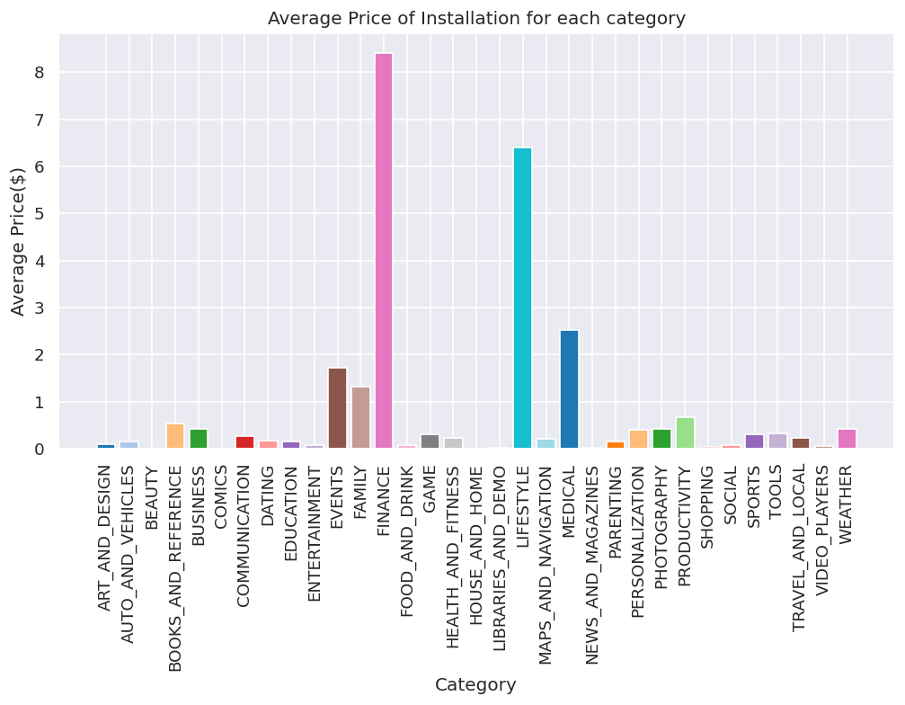

```python
# Chart - 08 visualization code
# Visualize the results using a bar chart
plt.bar(category_avg_price['Category'],category_avg_price['Price'],color=colors)
plt.xticks(rotation=90)
plt.xlabel('Category')
plt.ylabel('Average Price($)')
plt.title('Average Price of Installation for each category')
plt.show()
```

##### 1. Why did you pick the specific chart?

Answer: A **bar chart** allows viewers to easily compare the average prices in different categories. The viewer can quickly see which categories have the highest or lowest average price.

##### 2. What is/are the insight(s) found from the chart?

Answer:

1. FINANCE category having highest average price i.e. $ 8.4
2. LIBRARIES_AND_DEMO category having lowest average price $ 0.011786 and COMICS, BEAUTY ,HOUSE_AND_HOME are available free.

##### 3. Will the gained insights help creating a positive business impact?

Are there any insights that lead to negative growth? Justify with specific reason.

Answer:

Positive Business Impact: Only few downloads with such huge average price leads to high revenue generation.

Negative Business Impact: as finance having highest average price among all categories this is the reason that number of downloads is less

#### Chart 09-- What is the top 10 most downloaded apps from GAMES category?

```python
# Selects the top 10 games based on the number of installs from the dataframe
top_games=df1[df1['Category']=='GAME'].sort_values(by='Installs',ascending=False).head(10)
top_games
```

|  | App | Category | Rating | Reviews | Size | Installs | Type | Price | Content Rating | Genres | Last Updated | Current Ver | Android Ver | Revenue |
| --- | --- | --- | --- | --- | --- | --- | --- | --- | --- | --- | --- | --- | --- | --- |
| 1654 | Subway Surfers | GAME | 4.5 | 27722264 | 76.0 | 1000000000 | Free | 0.0 | Everyone 10+ | Arcade | 2018-07-12 | 1.90.0 | 4.1 and up | 0.0 |
| 1655 | Candy Crush Saga | GAME | 4.4 | 22426677 | 74.0 | 500000000 | Free | 0.0 | Everyone | Casual | 2018-07-05 | 1.129.0.2 | 4.1 and up | 0.0 |
| 1722 | My Talking Tom | GAME | 4.5 | 14891223 | NaN | 500000000 | Free | 0.0 | Everyone | Casual | 2018-07-19 | 4.8.0.132 | 4.1 and up | 0.0 |
| 1661 | Temple Run 2 | GAME | 4.3 | 8118609 | 62.0 | 500000000 | Free | 0.0 | Everyone | Action | 2018-07-05 | 1.49.1 | 4.0 and up | 0.0 |
| 1662 | Pou | GAME | 4.3 | 10485308 | 24.0 | 500000000 | Free | 0.0 | Everyone | Casual | 2018-05-25 | 1.4.77 | 4.0 and up | 0.0 |
| 1758 | Hungry Shark Evolution | GAME | 4.5 | 6074334 | 100.0 | 100000000 | Free | 0.0 | Teen | Arcade | 2018-07-25 | 6.0.0 | 4.1 and up | 0.0 |
| 9166 | Modern Combat 5: eSports FPS | GAME | 4.3 | 2903386 | 58.0 | 100000000 | Free | 0.0 | Mature 17+ | Action | 2018-07-24 | 3.2.1c | 4.0 and up | 0.0 |
| 5950 | Banana Kong | GAME | 4.4 | 3452530 | 68.0 | 100000000 | Free | 0.0 | Everyone | Action | 2018-02-07 | 1.9.6.6 | 4.0.3 and up | 0.0 |
| 1781 | Trivia Crack | GAME | 4.5 | 6427773 | 95.0 | 100000000 | Free | 0.0 | Everyone | Trivia | 2018-08-03 | 2.79.0 | 4.1 and up | 0.0 |
| 6554 | Skater Boy | GAME | 4.3 | 1167143 | 12.0 | 100000000 | Free | 0.0 | Everyone | Arcade | 2017-09-20 | 1.18.35 | 4.1 and up | 0.0 |

```python
# Total revenue generated by all top 10 games
top_games['Installs'].sum()
```

```
3500000000
```

```python
top_games.describe()
```

|  | Rating | Reviews | Size | Installs | Price | Revenue |
| --- | --- | --- | --- | --- | --- | --- |
| count | 10.000000 | 1.000000e+01 | 9.000000 | 1.000000e+01 | 10.0 | 10.0 |
| mean | 4.400000 | 1.036692e+07 | 63.222222 | 3.500000e+08 | 0.0 | 0.0 |
| std | 0.094281 | 8.783040e+06 | 29.273613 | 3.027650e+08 | 0.0 | 0.0 |
| min | 4.300000 | 1.167143e+06 | 12.000000 | 1.000000e+08 | 0.0 | 0.0 |
| 25% | 4.300000 | 4.107981e+06 | 58.000000 | 1.000000e+08 | 0.0 | 0.0 |
| 50% | 4.400000 | 7.273191e+06 | 68.000000 | 3.000000e+08 | 0.0 | 0.0 |
| 75% | 4.500000 | 1.378974e+07 | 76.000000 | 5.000000e+08 | 0.0 | 0.0 |
| max | 4.500000 | 2.772226e+07 | 100.000000 | 1.000000e+09 | 0.0 | 0.0 |

```python
# Chart 09- visualization code
# Visualize the results using a bar chart

fig = px.bar(top_games, x='Installs',y='App', title='Most Downloaded GAMES on the Play Store',
             width=1200, height=600,color='App',color_discrete_sequence=px.colors.sequential.Viridis)
fig.update_traces(marker_line_width=0.5)
fig.show()
```

[interactive chart not shown]

##### 1. Why did you pick the specific chart?

Answer: A **bar chart** allows viewers to easily compare the number of downloads from GAME category. The viewer can quickly see which game have the maximum number of downloads.

##### 2. What is/are the insight(s) found from the chart?

Answer:

1. Most downloaded App from game category is **Subway Surfers** with 1 Billion+ downloads followed by Candy Crush Saga, My Talking Tom.
2. .All of the top 5 most downloaded games on the Play Store have 500 million+downloads, indicating a high level of popularity among users.
3. All of the top 10 games are free to download, but generate revenue through in-app purchases and/or ads.
4. Most of the top 10 games have EVERYONE content rating.

##### 3. Will the gained insights help creating a positive business impact?

Are there any insights that lead to negative growth? Justify with specific reason.

Answer: Positive Impact:

1. Mobile gaming has potential for growth and profit due to its popularity.
2. Game developers should take popular games features into consideration while developing new games.

Negative Impact:

1. New games must compete with very popular games to stand out and attract users.
2. In-app purchases and frequent ads can lead to a negative user experience and uninstallation of a game.

#### Chart 10-- What is the average app size across different categories??

```python
# To get average size of app from each category
avg_appsize=df1.groupby(['Category'])['Size'].median().reset_index()
```

```python
# Sorting app size by descending order
avg_appsize.sort_values(by='Size',ascending=False)
```

|  | Category | Size |
| --- | --- | --- |
| 14 | GAME | 38.00 |
| 28 | SPORTS | 20.00 |
| 11 | FAMILY | 19.00 |
| 9 | ENTERTAINMENT | 18.50 |
| 30 | TRAVEL_AND_LOCAL | 18.00 |
| 13 | FOOD_AND_DRINK | 17.00 |
| 1 | AUTO_AND_VEHICLES | 16.00 |
| 8 | EDUCATION | 15.00 |
| 20 | MEDICAL | 15.00 |
| 26 | SHOPPING | 12.00 |
| 12 | FINANCE | 12.00 |
| 22 | PARENTING | 11.00 |
| 7 | DATING | 11.00 |
| 15 | HEALTH_AND_FITNESS | 11.00 |
| 5 | COMICS | 10.00 |
| 19 | MAPS_AND_NAVIGATION | 9.80 |
| 10 | EVENTS | 9.70 |
| 24 | PHOTOGRAPHY | 9.65 |
| 18 | LIFESTYLE | 9.60 |
| 16 | HOUSE_AND_HOME | 9.45 |
| 32 | WEATHER | 9.20 |
| 2 | BEAUTY | 9.20 |
| 21 | NEWS_AND_MAGAZINES | 9.00 |
| 0 | ART_AND_DESIGN | 8.95 |
| 4 | BUSINESS | 8.60 |
| 27 | SOCIAL | 8.00 |
| 31 | VIDEO_PLAYERS | 7.50 |
| 3 | BOOKS_AND_REFERENCE | 7.35 |
| 23 | PERSONALIZATION | 7.10 |
| 25 | PRODUCTIVITY | 6.90 |
| 6 | COMMUNICATION | 5.70 |
| 29 | TOOLS | 4.20 |
| 17 | LIBRARIES_AND_DEMO | 3.10 |

```python
# Chart 10- visualization code
# Create a bar plot of app size by category using plotly
fig = px.bar(avg_appsize, x="Category", y="Size", title='Distribution of App Size by Category',width=1000,height=500,color='Size')
fig.update_xaxes(title_text='App Category')
fig.update_yaxes(title_text='Size (in MB)')
fig.show()
```

[interactive chart not shown]

##### 1. Why did you pick the specific chart?

Answer: A **bar chart** allows viewers to easily compare the average app size in different categories. The viewer can quickly see which categories have the highest or lowest average app size.

##### 3. Will the gained insights help creating a positive business impact?

Are there any insights that lead to negative growth? Justify with specific reason.

Answer: Positive Impact: The analysis shows that the GAME category has the highest number of downloads, and on average, the app size for this category is 38.00 MB. Based on this insight, developers should take this information into consideration when planning to launch new apps in this category.

Negative Impact: Developers should not optimize their app size too much, as this can lead to lost features or functionality, which can negatively impact performance as in case of LIBRARIES_AND_DEMO( Only 52995910 downloads)

#### Chart 11-- Average rating and total reviews by Category.

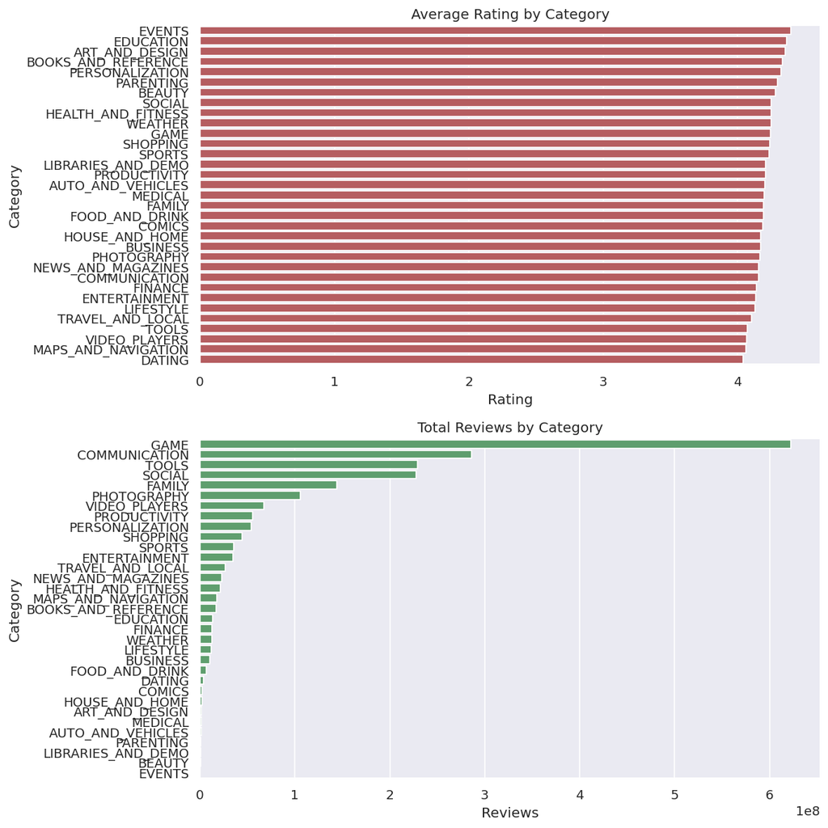

```python
# Chart - 11 visualization code

# Group the DataFrame by app category and calculate the mean rating and number of reviews for each category
category_ratings = df1.groupby(['Category'])['Rating'].mean().reset_index()
category_reviews = df1.groupby(['Category'])['Reviews'].sum().reset_index()

# Sort the DataFrame by rating or number of reviews to identify the categories with the highest values
category_ratings = category_ratings.sort_values('Rating', ascending=False)
category_reviews = category_reviews.sort_values('Reviews', ascending=False)

# Visualize the results using a bar chart or other appropriate plot
fig, axes = plt.subplots(nrows=2, figsize=(10,10))

sns.barplot(ax=axes[0], x='Rating', y='Category', data=category_ratings, color='r')
sns.barplot(ax=axes[1], x='Reviews', y='Category', data=category_reviews, color='g')

axes[0].set(title='Average Rating by Category', xlabel='Rating', ylabel='Category')
axes[1].set(title='Total Reviews by Category', xlabel='Reviews', ylabel='Category')

plt.tight_layout()
plt.show()
```

```python
# Apply inner join on category ratings category reviews dataframe
merged_df = pd.merge(category_ratings,category_reviews, on='Category', how='inner')
```

```python
merged_df[(merged_df['Rating']==merged_df['Rating'].max())]
```

|  | Category | Rating | Reviews |
| --- | --- | --- | --- |
| 0 | EVENTS | 4.395313 | 161018 |

##### 1. Why did you pick the specific chart?

Answer.

This graph shows the average rating and total reviews of app categories, making it a good choice for identifying popular categories based on user ratings and reviews.

##### 3. Will the gained insights help creating a positive business impact?

Are there any insights that lead to negative growth? Justify with specific reason.

Answer:

Positive business insights:

1. The category **Events** has the highest average rating, which means that users are generally satisfied with the apps in this category.
2. The category **GAME** has the highest number of reviews, which indicates that there is high user engagement with apps in this category.

Negative business insights:

1. The category **EVENTS** has the highest average rating, but lowest number of reviews which may indicate that users are satisfied with the apps in this category but didn't reviewed the category. Just by rating we can't judge the sentiment is positive or negative.

#### Chart 12-- Which is the **highest** earning App category on Play Store?

```python
# To get highest revenue generating categories
Most_paid=df1.groupby('Category')[['Revenue']].sum().reset_index()
```

```python
# To find highest earning category
Most_paid[Most_paid['Revenue']==Most_paid['Revenue'].max()]
```

|  | Category | Revenue |
| --- | --- | --- |
| 11 | FAMILY | 1.136798e+08 |

```python
# To find out lowest earning category
Most_paid[Most_paid['Revenue']==Most_paid['Revenue'].min()]
```

|  | Category | Revenue |
| --- | --- | --- |
| 2 | BEAUTY | 0.0 |
| 5 | COMICS | 0.0 |
| 16 | HOUSE_AND_HOME | 0.0 |

```python
# Chart - 12 visualization code
import plotly.express as px
# Create a bar plot using plotly
fig = px.bar(Most_paid, x='Category', y='Revenue',title='Most paid Apps Category in Playstore', width=1100, height=600,color='Revenue')
# Show the plot
fig.show()
```

[interactive chart not shown]

##### 1. Why did you pick the specific chart?

Answer: A **bar chart** allows viewers to easily compare the revenue generated by each apps categories. The viewer can quickly see which category have highest or lowest revenue generation.

##### 2. What is/are the insight(s) found from the chart?

Answer

Highest earning App category = **FAMILY**

Lowest/No earning App categogy = **BEAUTY, COMICS, HOUSE_AND_HOME**

##### 3. Will the gained insights help creating a positive business impact? Are there any insights that lead to negative growth? Justify with specific reason.

Answer: From bar chart we can notice that if developer planning to launch any app in FAMILY category new app have to compete with popular apps of the same category

#### Chart 13-- What is Overall Revenue trend over past few years for highest earning app category?

```python
# to get category wise yearly revenue..
df1['Year'] = df1['Last Updated'].dt.strftime('%Y')
df_yearwise=df1.groupby(['Year','Category'])['Revenue'].sum().reset_index()
```

```python
# As family is highest earning Category lets find out yearwise revenue of Family category
fam_yearwise=df_yearwise[df_yearwise['Category']=='FAMILY']
```

```python
fam_yearwise
```

|  | Year | Category | Revenue |
| --- | --- | --- | --- |
| 0 | 2010 | FAMILY | 0.00 |
| 3 | 2011 | FAMILY | 0.00 |
| 10 | 2012 | FAMILY | 267.40 |
| 24 | 2013 | FAMILY | 184602.40 |
| 47 | 2014 | FAMILY | 2739296.39 |
| 70 | 2015 | FAMILY | 2125047.45 |
| 100 | 2016 | FAMILY | 4338721.55 |
| 133 | 2017 | FAMILY | 11068130.88 |
| 166 | 2018 | FAMILY | 93223769.39 |

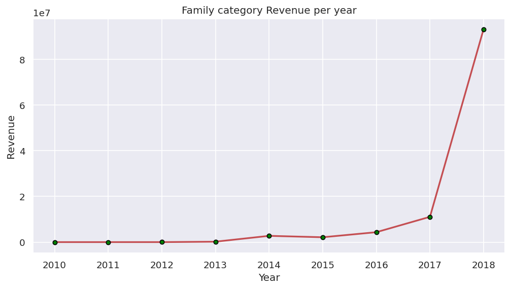

```python
# Chart - 13 visualization code
# Create a new figure and axis object
fig, ax = plt.subplots()

# Plot the data as a line chart
ax.plot(fam_yearwise['Year'], fam_yearwise['Revenue'], color='r', linewidth=2, linestyle='-', marker='o', markersize=5, markerfacecolor='green', markeredgecolor='black')

# Set the title and axis labels
ax.set_title('Family category Revenue per year')
ax.set_xlabel('Year')
ax.set_ylabel('Revenue')

# Show the chart
plt.show()
```

##### 1. Why did you pick the specific chart?

Answer:

This chart is suitable because it helps to visualize the revenue trend for the family category over time

##### 2. What is/are the insight(s) found from the chart?

Answer:

1. For first two years there was no revenue for Family category
2. The graph indicates that there is exponential growth in revenue.

##### 3. Will the gained insights help creating a positive business impact?

Are there any insights that lead to negative growth? Justify with specific reason.

Answer:

Positive business impact:

Understand the overall trend of revenue over time and identify any areas for improvement or growth.

Negative business impact:

May not provide detailed insights into the factors driving revenue or any changes in user behavior.

#### Chart 14-- Top 10 Highest earning Apps

```python
# To find out top 10 highest earning apps
highest_earning_df=df1.sort_values(by='Revenue',ascending=False)[['App','Price','Installs','Revenue']].head(10)
highest_earning_df
```

|  | App | Price | Installs | Revenue |
| --- | --- | --- | --- | --- |
| 2241 | Minecraft | 6.99 | 10000000 | 69900000.0 |
| 5351 | I am rich | 399.99 | 100000 | 39999000.0 |
| 5356 | I Am Rich Premium | 399.99 | 50000 | 19999500.0 |
| 4034 | Hitman Sniper | 0.99 | 10000000 | 9900000.0 |
| 7417 | Grand Theft Auto: San Andreas | 6.99 | 1000000 | 6990000.0 |
| 2883 | Facetune - For Free | 5.99 | 1000000 | 5990000.0 |
| 5578 | Sleep as Android Unlock | 5.99 | 1000000 | 5990000.0 |
| 8804 | DraStic DS Emulator | 4.99 | 1000000 | 4990000.0 |
| 4367 | I'm Rich - Trump Edition | 400.00 | 10000 | 4000000.0 |
| 5354 | I am Rich Plus | 399.99 | 10000 | 3999900.0 |

```python
# Total revenue generated by all top 10 apps
highest_earning_df['Revenue'].sum()
```

```
171758400.0
```

```python
# Chart - 14 visualization code
import plotly.express as px
# Create a bar plot using plotly
fig = px.bar(highest_earning_df[::-1], x='Revenue', y='App',title='Top 10 Highest earning Apps',color='App')

# Show the plot
fig.show()
```

[interactive chart not shown]

##### 1. Why did you pick the specific chart?

Answer:

This Bar chart will help us to identify the highest paid applications and total revenue generated.

##### 2. What is/are the insight(s) found from the chart?

Answer

1. Minecraft app is highest earning app having revenue about 69.9 M USD $.
2. I am rich plus is the lowest earnig app among top 10.
3. Total revenue generated by all top 10 apps is 171.75 M USD $.

##### 3. Will the gained insights help creating a positive business impact?

Are there any insights that lead to negative growth? Justify with specific reason.

Answer:

Positive impact:

Popular apps with high installs and revenue, priced from $0.99 to 6.99, have the potential for profitability and customer appeal. Examples include Minecraft, Hitman Sniper, Grand Theft Auto: San Andreas, Facetune, Sleep as Android Unlock, and DraStic DS Emulator

Negative impact:

Expensive apps like I am Rich, I Am Rich Premium, I'm Rich - Trump Edition, and I am Rich Plus have low installs and are not sustainable due to their high price. This pricing strategy may lead to negative reviews and harm brand reputation.

#### Chart 15-- Best performing App from each Category

```python
# Group by category and sum the number of downloads
category_downloads = df1.groupby('Category')['Installs'].sum().reset_index()

# Sort the groups by the number of downloads in descending order
category_downloads = category_downloads.sort_values('Installs', ascending=False)

# Display the top-performing app in each category
top_apps = []
for category in category_downloads['Category']:
    group = df1[df1['Category'] == category]
    top_app = group.loc[group['Installs'].idxmax()]
    top_apps.append(top_app)
    top_apps_df = pd.DataFrame(top_apps)
print(top_apps_df)
```

```
                                                    App             Category  \
1654                                     Subway Surfers                 GAME
335            Messenger – Text and Video Chat for Free        COMMUNICATION
3234                                             Google                TOOLS
3454                                       Google Drive         PRODUCTIVITY
2544                                           Facebook               SOCIAL
2808                                      Google Photos          PHOTOGRAPHY
3975                                            Hay Day               FAMILY
3665                                            YouTube        VIDEO_PLAYERS
3117                          Maps - Navigate & Explore     TRAVEL_AND_LOCAL
3736                                        Google News   NEWS_AND_MAGAZINES
865                                   Google Play Games        ENTERTAINMENT
152                                   Google Play Books  BOOKS_AND_REFERENCE
3354                      ZEDGE™ Ringtones & Wallpapers      PERSONALIZATION
2655                           Wish - Shopping Made Fun             SHOPPING
```

[output cut: 124 more lines]

```python
# To get list of best performing app from each category
top_apps_df[['App','Category', 'Installs','Revenue']]
```

|  | App | Category | Installs | Revenue |
| --- | --- | --- | --- | --- |
| 1654 | Subway Surfers | GAME | 1000000000 | 0.0 |
| 335 | Messenger – Text and Video Chat for Free | COMMUNICATION | 1000000000 | 0.0 |
| 3234 | Google | TOOLS | 1000000000 | 0.0 |
| 3454 | Google Drive | PRODUCTIVITY | 1000000000 | 0.0 |
| 2544 | Facebook | SOCIAL | 1000000000 | 0.0 |
| 2808 | Google Photos | PHOTOGRAPHY | 1000000000 | 0.0 |
| 3975 | Hay Day | FAMILY | 100000000 | 0.0 |
| 3665 | YouTube | VIDEO_PLAYERS | 1000000000 | 0.0 |
| 3117 | Maps - Navigate & Explore | TRAVEL_AND_LOCAL | 1000000000 | 0.0 |
| 3736 | Google News | NEWS_AND_MAGAZINES | 1000000000 | 0.0 |
| 865 | Google Play Games | ENTERTAINMENT | 1000000000 | 0.0 |
| 152 | Google Play Books | BOOKS_AND_REFERENCE | 1000000000 | 0.0 |
| 3354 | ZEDGE™ Ringtones & Wallpapers | PERSONALIZATION | 100000000 | 0.0 |
| 2655 | Wish - Shopping Made Fun | SHOPPING | 100000000 | 0.0 |
| 5596 | Samsung Health | HEALTH_AND_FITNESS | 500000000 | 0.0 |
| 4054 | 3D Bowling | SPORTS | 100000000 | 0.0 |
| 194 | OfficeSuite : Free Office + PDF Editor | BUSINESS | 100000000 | 0.0 |
| 4587 | Tinder | LIFESTYLE | 100000000 | 0.0 |
| 3820 | Waze - GPS, Maps, Traffic Alerts & Live Naviga... | MAPS_AND_NAVIGATION | 100000000 | 0.0 |
| 1083 | Google Pay | FINANCE | 100000000 | 0.0 |
| 3626 | The Weather Channel: Rain Forecast & Storm Alerts | WEATHER | 50000000 | 0.0 |
| 699 | Duolingo: Learn Languages Free | EDUCATION | 100000000 | 0.0 |
| 1176 | McDonald's | FOOD_AND_DRINK | 10000000 | 0.0 |
| 482 | Zoosk Dating App: Meet Singles | DATING | 10000000 | 0.0 |
| 3 | Sketch - Draw & Paint | ART_AND_DESIGN | 50000000 | 0.0 |
| 1446 | Zillow: Find Houses for Sale & Apartments for ... | HOUSE_AND_HOME | 10000000 | 0.0 |
| 72 | Android Auto - Maps, Media, Messaging & Voice | AUTO_AND_VEHICLES | 10000000 | 0.0 |
| 1523 | Aviary Stickers: Free Pack | LIBRARIES_AND_DEMO | 10000000 | 0.0 |
| 297 | LINE WEBTOON - Free Comics | COMICS | 10000000 | 0.0 |
| 2310 | Blood Pressure | MEDICAL | 5000000 | 0.0 |
| 7229 | Pregnancy Tracker & Countdown to Baby Due Date | PARENTING | 10000000 | 0.0 |
| 117 | Beauty Camera - Selfie Camera | BEAUTY | 10000000 | 0.0 |
| 1005 | Ticketmaster Event Tickets | EVENTS | 5000000 | 0.0 |

```python
# best performing categories in terms of downloads
top_apps_df[['Installs','Category']].sort_values(by='Installs',ascending=False).head(10)
```

|  | Installs | Category |
| --- | --- | --- |
| 1654 | 1000000000 | GAME |
| 335 | 1000000000 | COMMUNICATION |
| 3234 | 1000000000 | TOOLS |
| 3454 | 1000000000 | PRODUCTIVITY |
| 2544 | 1000000000 | SOCIAL |
| 2808 | 1000000000 | PHOTOGRAPHY |
| 3665 | 1000000000 | VIDEO_PLAYERS |
| 3117 | 1000000000 | TRAVEL_AND_LOCAL |
| 3736 | 1000000000 | NEWS_AND_MAGAZINES |
| 865 | 1000000000 | ENTERTAINMENT |

```python
# worst performing category in terms of downloads
top_apps_df[top_apps_df['Installs']==top_apps_df['Installs'].min()]
```

|  | App | Category | Rating | Reviews | Size | Installs | Type | Price | Content Rating | Genres | Last Updated | Current Ver | Android Ver | Revenue | Year |
| --- | --- | --- | --- | --- | --- | --- | --- | --- | --- | --- | --- | --- | --- | --- | --- |
| 2310 | Blood Pressure | MEDICAL | 4.2 | 33033 | 7.4 | 5000000 | Free | 0.0 | Everyone | Medical | 2018-07-24 | 3.27.3 | 4.1 and up | 0.0 | 2018 |
| 1005 | Ticketmaster Event Tickets | EVENTS | 4.0 | 40113 | 36.0 | 5000000 | Free | 0.0 | Everyone | Events | 2018-07-23 | Varies with device | Varies with device | 0.0 | 2018 |

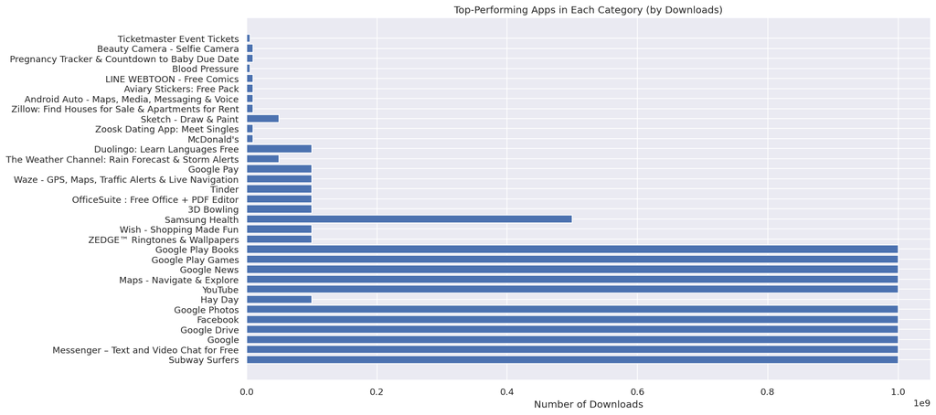

```python
# Chart - 15 visualization code

# Create a horizontal bar chart of the top-performing apps
fig, ax = plt.subplots(figsize=(15, 8))
app_names = [app['App'] for app in top_apps]
downloads = [app['Installs'] for app in top_apps]
ax.barh(app_names, downloads)
ax.set_xlabel('Number of Downloads')
ax.set_title('Top-Performing Apps in Each Category (by Downloads)')
plt.show()
```

##### 1. Why did you pick the specific chart?

Answer.

It is effective for visualizing a large amount of data and identifying the most successful apps in a given category available on play store.

##### 3. Will the gained insights help creating a positive business impact?

Are there any insights that lead to negative growth? Justify with specific reason.

Answer:

Positive Impact: By studying the top performing category and respective app developer and business owner can work on perticular feature or function for which the app is downloaded and take necessary decisions before launching app.

Negative Impact:There maybe chances that develpers may ignore smaller market shares like 'MEDICAL' & 'EVENTS' if they only concentrate on top performing apps and trending categories.

#### Chart 16-- Average Number of Apps installed every year.

```python
# To get number of average installs per year
Installs_per_year=df1.groupby(['Year'])['Installs'].mean().reset_index()
```

```python
Installs_per_year
```

|  | Year | Installs |
| --- | --- | --- |
| 0 | 2010 | 1.000000e+05 |
| 1 | 2011 | 1.160473e+06 |
| 2 | 2012 | 5.381619e+05 |
| 3 | 2013 | 9.545034e+05 |
| 4 | 2014 | 1.328991e+06 |
| 5 | 2015 | 9.047756e+05 |
| 6 | 2016 | 1.659006e+06 |
| 7 | 2017 | 1.617161e+06 |
| 8 | 2018 | 1.117040e+07 |

```python
# Chart 16- visualization code
# Create the line chart using Plotly
fig = px.bar(Installs_per_year, x='Year', y='Installs', title='Average Installs per Year',width=1050, height=600, color='Year')
fig.show()
```

[interactive chart not shown]

##### 1. Why did you pick the specific chart?

Answer: Bar plot is useful to visualise the average number of apps installed per year

##### 2. What is/are the insight(s) found from the chart?

Answer:

1. The number of average installs done over year on play store increased drastically for year 2018.
2. year 2010 have least number of downloads.

##### 3. Will the gained insights help creating a positive business impact?

Are there any insights that lead to negative growth? Justify with specific reason.

Answer:

From the given graph it's clearly visible that average number of apps installed increased significantly over years which indicates positive impact on business as it indicates good business growth.

But on the other hand there is negative impact also which indicates growth in competition over time which makes difficult for new apps to stand in such crowded market.

#### Chart 17-- Top apps with the highest number of POSITIVE reviews and categories.

```python
#  Enlisting top apps with positive reviews
Positive_sent = df2[df2['Sentiment']=='Positive']

# sorting positive sentiment dataset in descending order
top_10_positive = Positive_sent.groupby('App')[['Sentiment']].count().sort_values(by='Sentiment',ascending=False).reset_index().head(10)
```

```python
# top 10 apps with highest positive reviews
top_10_positive
```

|  | App | Sentiment |
| --- | --- | --- |
| 0 | Helix Jump | 209 |
| 1 | Duolingo: Learn Languages Free | 200 |
| 2 | Calorie Counter - Macros | 174 |
| 3 | Calorie Counter - MyFitnessPal | 169 |
| 4 | Bowmasters | 169 |
| 5 | 10 Best Foods for You | 162 |
| 6 | Google Photos | 143 |
| 7 | 8fit Workouts & Meal Planner | 137 |
| 8 | Garena Free Fire | 136 |
| 9 | DRAGON BALL LEGENDS | 127 |

```python
# to get apps list
app_list=top_10_positive['App'].tolist()
print(app_list)
```

```
['Helix Jump', 'Duolingo: Learn Languages Free', 'Calorie Counter - Macros', 'Calorie Counter - MyFitnessPal', 'Bowmasters', '10 Best Foods for You', 'Google Photos', '8fit Workouts & Meal Planner', 'Garena Free Fire', 'DRAGON BALL LEGENDS']
```

```python
# to get list of categories for specific app
category_list = []
for i in app_list:
  category_list.append(df1[df1['App']==i].iloc[0,1])
print(category_list)
```

```
['GAME', 'EDUCATION', 'HEALTH_AND_FITNESS', 'HEALTH_AND_FITNESS', 'GAME', 'HEALTH_AND_FITNESS', 'PHOTOGRAPHY', 'HEALTH_AND_FITNESS', 'GAME', 'GAME']
```

```python
# To add new column 'Category' in top 10 positive app reviews dataframe
top_10_positive['Category'] = category_list
```

```python
# Dataframe with top 10 apps with positive reviews along with category
top_10_positive
```

|  | App | Sentiment | Category |
| --- | --- | --- | --- |
| 0 | Helix Jump | 209 | GAME |
| 1 | Duolingo: Learn Languages Free | 200 | EDUCATION |
| 2 | Calorie Counter - Macros | 174 | HEALTH_AND_FITNESS |
| 3 | Calorie Counter - MyFitnessPal | 169 | HEALTH_AND_FITNESS |
| 4 | Bowmasters | 169 | GAME |
| 5 | 10 Best Foods for You | 162 | HEALTH_AND_FITNESS |
| 6 | Google Photos | 143 | PHOTOGRAPHY |
| 7 | 8fit Workouts & Meal Planner | 137 | HEALTH_AND_FITNESS |
| 8 | Garena Free Fire | 136 | GAME |
| 9 | DRAGON BALL LEGENDS | 127 | GAME |

```python
# Chart 17 -  visualization code

# Create a horizontal bar chart of the top 10 apps with highest positive sentiment based on reviews
fig = px.bar(top_10_positive, x='Sentiment', y='App', title='Top 10 Apps with Highest Positive Sentimental Reviews',
             orientation='h', width=800, height=500, color='Sentiment',
             color_continuous_scale=px.colors.sequential.Greens,)
fig.show()
```

[interactive chart not shown]

##### 1. Why did you pick the specific chart?

Answer:

A bar chart allows viewers to easily compare the number of positive reviews for top 10 apps. The viewer can quickly see which app have highest or lowest number of positive sentiments.

##### 2. What is/are the insight(s) found from the chart?

Answer:

1. App with most positive sentiments= Helix Jump (209 positive reviews)
2. From the list of top 10 apps, DRAGON BALL LEGENDS having least number of positive reviews(127 reviews)

##### 3. Will the gained insights help creating a positive business impact?

Are there any insights that lead to negative growth? Justify with specific reason.

Answer:

Positive Impact: From the data given above it is clearly visible that most of the apps from top 10 positively reviewed list belongs to GAME and **HEALTH_AND_FITNESS** category.

Negative Impact: The graph doesn't indicate any clear negative business impact, but in order to prevent bad reviews and low ratings, businesses should put the user experience first.

#### Chart 18-- Top apps with the highest number of NEGATIVE reviews and categories.

```python
#  Enlisting top apps with neative reviews
Negative_sent=df2[df2['Sentiment']=='Negative']
top_10_negative=Negative_sent.groupby('App')[['Sentiment']].count().sort_values(by='Sentiment',ascending=False).reset_index().head(10)
```

```python
# top 10 apps with most negative reviews
top_10_negative
```

|  | App | Sentiment |
| --- | --- | --- |
| 0 | Angry Birds Classic | 147 |
| 1 | Candy Crush Saga | 126 |
| 2 | Bowmasters | 119 |
| 3 | 8 Ball Pool | 106 |
| 4 | Candy Crush Soda Saga | 96 |
| 5 | Garena Free Fire | 81 |
| 6 | Cooking Fever | 79 |
| 7 | Alto's Adventure | 72 |
| 8 | Block Puzzle | 71 |
| 9 | Agar.io | 66 |

```python
# to get negative reviews apps list
app_list_negative=top_10_negative['App'].tolist()
print(app_list_negative)
```

```
['Angry Birds Classic', 'Candy Crush Saga', 'Bowmasters', '8 Ball Pool', 'Candy Crush Soda Saga', 'Garena Free Fire', 'Cooking Fever', "Alto's Adventure", 'Block Puzzle', 'Agar.io']
```

```python
# to get list of categories for specific app
category_list_negative=[]
for i in app_list:
  category_list_negative.append(df1[df1['App']==i].iloc[0,1])
print(category_list_negative)
```

[output not shown]

```python
# To add new column 'Category' in top 10 negative app reviews dataframe
top_10_negative['Category']=category_list_negative
```

```python
# Dataframe with top 10 apps with negative reviews along with category
top_10_negative
```

[output not shown]

```python
# Chart 18 - visualization code
# Create a horizontal bar chart of the top 10 apps with most negative sentiment based on reviews
fig = px.bar(top_10_negative, x='Sentiment', y='App', title='Top 10 Apps with Highest Negative Sentimental Reviews',
             orientation='h', width=800, height=500,color='Sentiment',
             color_continuous_scale=px.colors.sequential.Reds)
fig.show()
```

[interactive chart not shown]

##### 1. Why did you pick the specific chart?

Answer:

A bar chart allows viewers to easily compare the number of Negative reviews for top 10 apps. The viewer can quickly see which app have highest number of Negative sentiments.

##### 3. Will the gained insights help creating a positive business impact?

Are there any insights that lead to negative growth? Justify with specific reason.

Answer:

Positive Impact: Game developers can use insights to improve their game quality and address user issues, which indirectly leads to increased downloads and positive reviews.

Negative Impact: Users may uninstall the game and switch to a better alternative, leading to a decrease in downloads and revenue. If reviews are not taken seriously, this could have a negative impact.

#### Chart 19-- Sentiment Distribution with Pie chart

```python
# Chart 19- visualization code

# create a DataFrame with sentiment counts
df2=df2.dropna()
sentiment_counts = df2['Sentiment'].value_counts().reset_index()

# create a pie chart
fig = px.pie(sentiment_counts, values='Sentiment', names='index',
             title='Sentiment Distribution on Play Store',width=800, height=500,hole=.5)

# show the plot
fig.show()
```

[interactive chart not shown]

```python
# Total number of positive, negative and neutral sentiments.
sentiment_counts
```

|  | index | Sentiment |
| --- | --- | --- |
| 0 | Positive | 23998 |
| 1 | Negative | 8271 |
| 2 | Neutral | 5158 |

```python
sentiment_counts['Sentiment'].sum()
```

```
37427
```

##### 1. Why did you pick the specific chart?

Answer:

Pie charts are an effective way to represent the distribution of categorical data, such as sentiment

##### 2. What is/are the insight(s) found from the chart?

Answer:

1. Users are generally satisfied with the apps available on the Play Store, with 64.1% of reviews being positive.
2. Almost 13.8% of Apps with neutral sentiment may indicate that users have mixed feelings or are not strongly inclined towards any particular sentiment.
3. As 8271 reviews are negative out off 37427 indicates 22.1% proportion of reviews are negative, which indicates developers can improve app features to improve user satisfaction.

##### 3. Will the gained insights help creating a positive business impact?

Are there any insights that lead to negative growth? Justify with specific reason.

Answer: Positive Impact: The majority of reviews are positive, which could lead to increased downloads, user engagement, and higher revenue. Developers just need to maintain quality in order to increase engagement.

Negative Impact: The chart shows a significant number of negative reviews, which could indicate areas where the app needs improvement. This could lead to decreased user engagement and lower revenue.

#### Chart 20-- Sentiment Subjectivity Distribution with Histogram

```python
# to join app data and user data on the basis of app column
merged_df = pd.merge(df1, df2, on='App', how = "inner")
```

```python
# Chart 20 - visualization code
# Create a histogram
fig = px.histogram(merged_df[['Sentiment_Subjectivity']],nbins=25)

# Show the figure
fig.show()
```

[interactive chart not shown]

##### 1. Why did you pick the specific chart?

Answer: to analyse sentiment subjectivity of Play Store data we should use a histogram to visualize the distribution of sentiment scores(Positive,Neutral, Negative)

##### 3. Will the gained insights help creating a positive business impact?

Are there any insights that lead to negative growth? Justify with specific reason.

Answer:

Positive Impact: Positive reviews with high sentiment subjectivity scores indicate emotional attachment to the app, leading to higher user retention and increased word-of-mouth marketing.

#### Chart 21-- Pair Plot

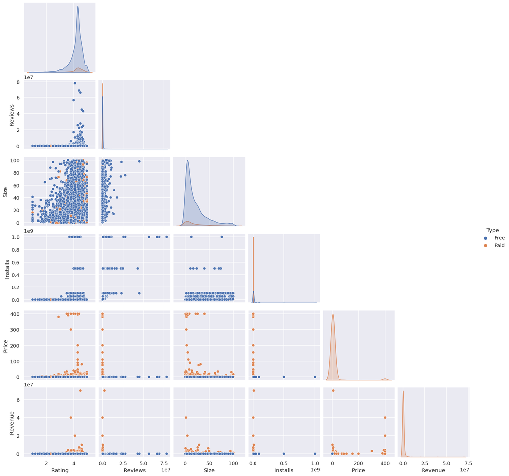

```python
# Chart 21 -  visualization code
# Pair Plot visualization code

sns.pairplot(df1, hue="Type",corner=True)
```

##### 1. Why did you pick the specific chart?

With the help of pairplot we can easily plot multiple graphs to observe relationship with different varaiables like rating, reviews, size, installs, price.

##### 2. What is/are the insight(s) found from the chart?

1. Apps which are small in size are available free on Play store.
2. Most of the apps have rating ranges from 3.5 to 4.5

#### Chart 22- Correlation Heatmap

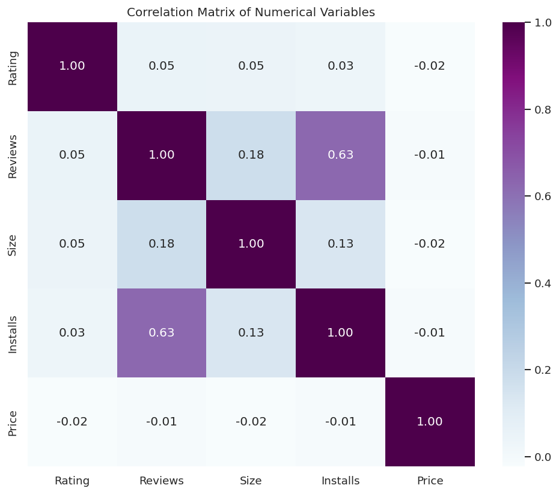

```python
# Chart 22 -  visualization code
# Correlation Heatmap visualization code

# Select only the numerical columns
numerical_cols = ['Rating', 'Reviews', 'Size', 'Installs', 'Price']

# Compute the correlation matrix
corr_data = df1[numerical_cols].corr()

# Create a heatmap of the correlation matrix
plt.figure(figsize=(10, 8))
sns.heatmap(corr_data, cmap='BuPu', annot=True, fmt='.2f')
plt.title('Correlation Matrix of Numerical Variables')
plt.show()
```

##### 1. Why did you pick the specific chart?

Creating a heatmap of all columns in a Play Store dataset can be overwhelming as there are many variables to consider. Instead, it's more common to create a heatmap of the correlation matrix of numerical variables to identify which variables are most correlated with each other.

## **5. Solution to Business Objective**

#### What do you suggest the client to achieve Business Objective ?

Explain Briefly.

Answer:

- Focus on developing apps in the top app categories such as Games, Family, and Tools to achieve high demand and popularity among users.
- Increase the number of free apps to attract more users, as the majority of the apps on the Play Store are free.
- For paid apps, keep the price range within $2 to $10 to attract more users, as this is the most common price range for paid apps.
- Develop more apps for Android 4.0 and above, as this is the most popular Android version among users.
- Improve the quality and user experience of apps by taking into account the ratings and reviews of best performing apps in the same category.
- Consider developing apps in categories with higher average ratings, as this can potentially lead to more downloads and higher user satisfaction.
- Analyze the user feedback and incorporate relevant suggestions and feature requests in the app updates to improve the user experience and increase user retention.

# **Conclusion**

## Detailed Insights from various variables (columns) available in Playstore Data as follows:

**1. CATEGORY**

Identifying popular app categories can help developers target specific categories and develop new apps to meet user needs.

a) Most popular category is **FAMILY** with **1829** apps available on playstore

b) In terms of downloads **GAME** with **13878924398** downloads with distribution of **18.47%**

**2. APP RATING**

a) Most of the apps available on playstore having rating 3 to 5.

b) The Average Rating on playstore is 4.191821

**3. APP SIZE**

a) Most of the apps on Playstore are of small size.

b) Average app size available on Playstore is 20 MB.

**4. APP INSTALLS**

b) Compared to paid apps(0.08%), free apps are more likely to be downloaded(99.92%)

c) GAMES, COMMUNICATION & TOOLS are the most popular catergories in terms of downloads.

**5. APP PRICE**

b) only few apps are available which cost high than average cost.

**6. APP TYPE (Free or Paid)**

92% of apps available are Free of cost and 8% of apps are PAID.

Most expensive app available on Play store is I'm Rich - Trump Edition with 10000+ downloads

**7. APP REVIEWS**

b) GAMES, COMMUNICATION, TOOLS categories are the most reviewed.

## Detailed Insights from various variables (columns) available in User review Data as follows:

**1. SENTIMENTS**

a) 64.1% of reviews are positive in nature.This can be a positive sign for the app developers as positive reviews can lead to increased downloads and higher ratings

b) 13.8% of reviews are neutral this means that users have not expressed any strong positive or negative sentiment towards the app.

c) 22.1% of reviews are of Negative sentiments,App developers should pay attention to negative reviews and take steps to address the issues raised by users to improve the overall user experience.

## Challenges and future scope:

**Challenges**

Missing data: A significant challenge in EDA on Play Store data is missing data. almost 13.6% data is missing from Rating variable.

Handling categorical data: Categorical data, such as ratings, and installs, Price need to be converted to numerical values for analysis.

**Future scope**

After data cleaning and data wrangling it comes to notice that 1225 apps still have null values in size column, dropping a large number of data is not an effective solution, even replacing with median or mean value will not work.

Sentiment analysis: Analyzing user reviews to determine the sentiment of the users towards the apps in details can be an interesting project.

User behavior analysis: Studying user behavior patterns such as app usage time, app preference, and app uninstallation reason can provide valuable insights to app developers.

### *Hurrah! You have successfully completed your EDA Capstone Project !!!*